# Tuesday - Jumpstart 2025

Dan Lane

2025-08-19

# Welcome to R for Communication Research!

Today In Group B we will be exploring mediation and moderation in R

## Today’s Learning Goals:

- Run basic moderation models

## Power Analysis In R

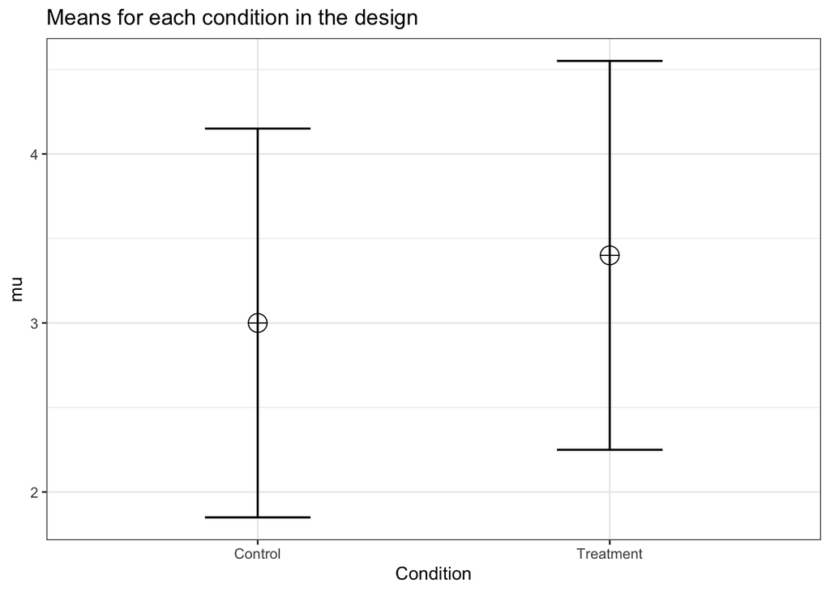

```r
design_result <- ANOVA_design(
  design = "2b", n = 131,
  mu = c(3,3.4), sd = 1.15,
  labelnames = c("Condition","Control",
                 "Treatment"),plot = TRUE)
```

```r
result_exact <- ANOVA_exact(design_result,emm = TRUE)
```

Power and Effect sizes for ANOVA tests power partial_eta_squared cohen_f non_centrality Condition 80.0848 0.0296 0.1746 7.9244

Power and Effect sizes for pairwise comparisons (t-tests) power effect_size p_Condition_Control_Condition_Treatment 80.08 0.35

Power and Effect sizes for estimated marginal means contrast power partial_eta_squared cohen_f 1 Condition_Control - Condition_Treatment 80.08 0.0296 0.1746 non_centrality 1 7.9244

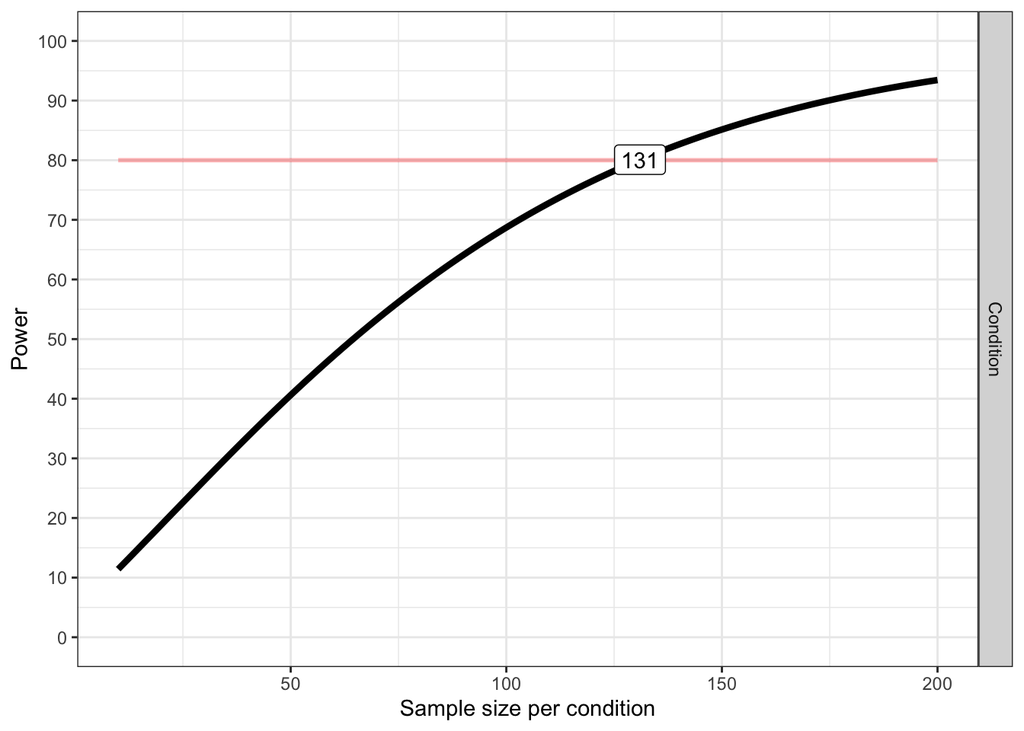

```r
plot_power(design_result,
           min_n = 10, max_n = 200,
           desired_power = 80, plot = TRUE)
```

Achieved Power and Sample Size for ANOVA-level effects variable label n achieved_power desired_power 1 Condition Desired Power Achieved 131 80.08 80

```r
131*2
```

[1] 262

```r
result_exact <- ANOVA_exact(design_result,emm = TRUE,emm_comp = "Condition")
```

Power and Effect sizes for ANOVA tests power partial_eta_squared cohen_f non_centrality Condition 80.0848 0.0296 0.1746 7.9244

Power and Effect sizes for pairwise comparisons (t-tests) power effect_size p_Condition_Control_Condition_Treatment 80.08 0.35

Power and Effect sizes for estimated marginal means contrast power partial_eta_squared cohen_f 1 Condition_Control - Condition_Treatment 80.08 0.0296 0.1746 non_centrality 1 7.9244